# Example Vignette

```r
library(sta380package.example)
```

This vignette merely serves as an example on how to use the three functions within the `sta380package.example` package for simulating the bivariate Gaussian distribution using three introductory MCMC methods:

- independent MH (Metropolis–Hastings) `sta380package.example::rbivariate.mh_ind()`,
- random walk MH `sta380package.example::rbivariate.rwmh()`, and
- the Gibbs sampler `sta380package.example::gibbs_sampler()`.

In particular, the following examples are for generating random vectors from the bivariate Gaussian distribution with $\mu_{1} = \mu_{2} = 0$, $\sigma_{1} = \sigma_{2} = 1$ and correlation $\rho = 0.7$.

We also include examples on what the resultant samples appear to be, and comparisons between the three functions.

# Independent Metropolis–Hastings

## Generating Samples

```r
set.seed(1)
N <- 10000
burn <- 100
rho <- 0.7
sigma_matrix <- matrix(c(1, rho, rho, 1), nrow = 2, ncol = 2)
mu_vec <- c(0, 0)
test_pt1 = rmvnorm(n = 1, mean = c(0, 0), sigma = sigma_matrix)
sim_attempt1 = rbivariate.mh_ind(N, burn, test_pt1, sigma_matrix, mu_vec)
```

## Scatterplot

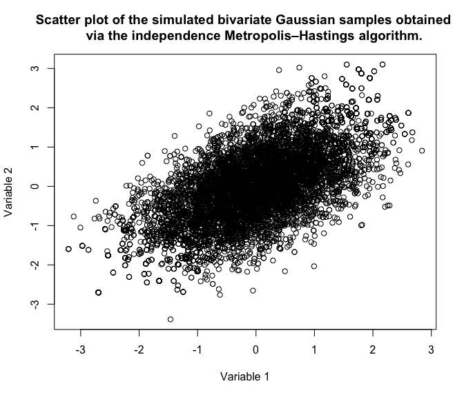

```r
par(mfcol=c(1,1))
plot(sim_attempt1[,1], sim_attempt1[,2],
     xlab = "Variable 1",
     ylab = "Variable 2",
     main = "Scatter plot of the simulated bivariate Gaussian samples obtained
     via the independence Metropolis–Hastings algorithm.")
```

## Checking Normality Assumptions

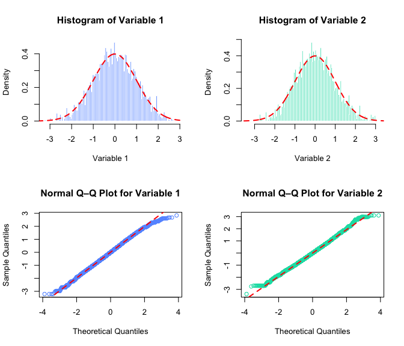

```r
par(mfcol=c(2,2))
xx = seq(-4,4,by=0.01)
hist(sim_attempt1[,1], breaks=100, freq=FALSE,
     main = "Histogram of Variable 1",
     xlab = "Variable 1",
     col = "#6699FF", border = "white")
lines(xx, dnorm(xx), col="red", lwd = 2, lty = 2)
qqnorm(sim_attempt1[,1], main = "Normal Q–Q Plot for Variable 1",
       col = "#6699FF")
qqline(sim_attempt1[,1], col="red", lwd = 2, lty = 2)

hist(sim_attempt1[,2], breaks=100, freq=FALSE,
     main = "Histogram of Variable 2",
     xlab = "Variable 2",
     col = "#05DEB2", border = "white")
lines(xx, dnorm(xx), col="red", lwd = 2, lty = 2)
qqnorm(sim_attempt1[,2], main = "Normal Q–Q Plot for Variable 2",
       col = "#05DEB2")
qqline(sim_attempt1[,2], col="red", lwd = 2, lty = 2)
```

# Random Walk Metropolis–Hastings

## Generating Samples

```r
set.seed(1)
N <- 10000
burn <- 100
rho <- 0.7
sigma_matrix <- matrix(c(1, rho, rho, 1), nrow = 2, ncol = 2)
mu_vec <- c(0, 0)
test_pt1 <- rmvnorm(n = 1, mean = c(0, 0), sigma = sigma_matrix)
sim_attempt2 <- rbivariate.rwmh(N, burn, test_pt1, sigma_matrix, mu_vec)
```

## Scatterplot

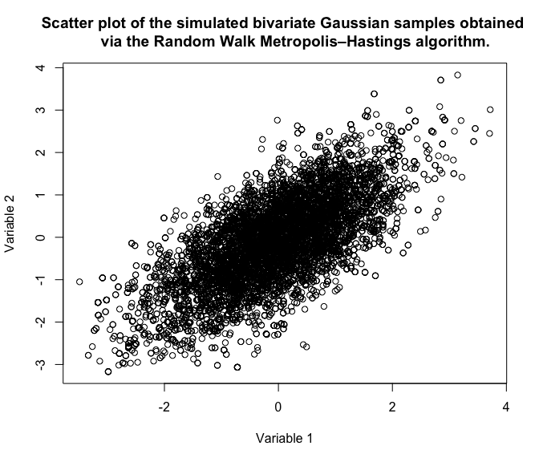

```r
par(mfcol=c(1,1))
plot(sim_attempt2[,1], sim_attempt2[,2],
     xlab = "Variable 1",
     ylab = "Variable 2",
     main = "Scatter plot of the simulated bivariate Gaussian samples obtained
     via the Random Walk Metropolis–Hastings algorithm.")
```

## Checking Normality Assumptions

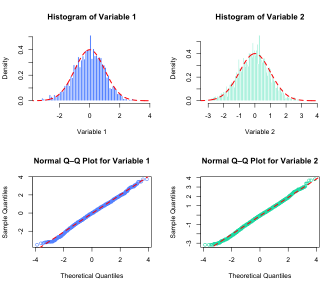

```r
par(mfcol=c(2,2))
xx = seq(-4,4,by=0.01)
hist(sim_attempt2[,1], breaks=100, freq=FALSE,
     main = "Histogram of Variable 1",
     xlab = "Variable 1",
     col = "#6699FF", border = "white")
lines(xx, dnorm(xx), col="red", lwd = 2, lty = 2)
qqnorm(sim_attempt2[,1], main = "Normal Q–Q Plot for Variable 1",
       col = "#6699FF")
qqline(sim_attempt2[,1], col="red", lwd = 2, lty = 2)

hist(sim_attempt2[,2], breaks=100, freq=FALSE,
     main = "Histogram of Variable 2",
     xlab = "Variable 2",
     col = "#05DEB2", border = "white")
lines(xx, dnorm(xx), col="red", lwd = 2, lty = 2)
qqnorm(sim_attempt2[,2], main = "Normal Q–Q Plot for Variable 2",
       col = "#05DEB2")
qqline(sim_attempt2[,2], col="red", lwd = 2, lty = 2)
```